# “College tuition, diversity, and pay”

Zahra Khoshmanesh, Vahid Azizi, and Saba Moeinizade

4/28/2020  
Zahra Khoshmanesh (slide number: 2-12), Vahid Azizi (slide number: 13-20), Saba Moeinizade (slide number: 21-31)

[figure not shown]

# Introduction

# Diversity dataset

```r
diversity_school %>% glimpse()
```

```
## Rows: 50,655
## Columns: 5
## $ name             <chr> "University of Phoenix-Arizona", "University of Ph...
## $ total_enrollment <dbl> 195059, 195059, 195059, 195059, 195059, 195059, 19...
## $ state            <chr> "Arizona", "Arizona", "Arizona", "Arizona", "Arizo...
## $ category         <chr> "Women", "American Indian / Alaska Native", "Asian...
## $ enrollment       <dbl> 134722, 876, 1959, 31455, 13984, 1019, 58209, 1903...
```

| name | total_enrollment | state | category | enrollment |
| --- | --- | --- | --- | --- |
| University of Phoenix-Arizona | 195059 | Arizona | Women | 134722 |
| University of Phoenix-Arizona | 195059 | Arizona | American Indian / Alaska Native | 876 |
| University of Phoenix-Arizona | 195059 | Arizona | Asian | 1959 |
| University of Phoenix-Arizona | 195059 | Arizona | Black | 31455 |
| University of Phoenix-Arizona | 195059 | Arizona | Hispanic | 13984 |
| University of Phoenix-Arizona | 195059 | Arizona | Native Hawaiian / Pacific Islander | 1019 |

# Bar chart of all diversity categories and ethnicity groups in the US college

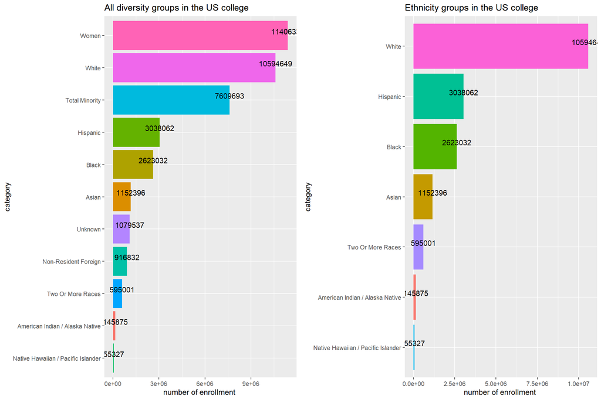

# Finding the most diverse campus for each diversity category

| category | university_name | state | enrollment_rate | total_enroll | category_enroll |
| --- | --- | --- | --- | --- | --- |
| American Indian / Alaska Native | Haskell Indian Nations University | Kansas | 100.00000 | 808 | 808 |
| Asian | Grace Mission University | California | 95.45455 | 88 | 84 |
| Black | Lane College | Tennessee | 100.00000 | 1262 | 1262 |
| Hispanic | Professional Hands Institute | Florida | 100.00000 | 37 | 37 |
| Native Hawaiian / Pacific Islander | Argosy University at Honolulu | Hawaii | 49.73205 | 933 | 464 |
| Non-Resident Foreign | Knowledge Systems Institute | Illinois | 97.92746 | 193 | 189 |
| Total Minority | Lane College | Tennessee | 100.00000 | 1262 | 1262 |
| Two Or More Races | University of Hawaii Windward Community College | Hawaii | 40.13529 | 2661 | 1068 |
| Unknown | Le Cordon Bleu College of Culinary Arts at San Francisco | California | 90.27149 | 442 | 399 |
| White | Rabbinical Seminary of America | New York | 100.00000 | 500 | 500 |
| Women | Spelman College | Georgia | 100.00000 | 2135 | 2135 |

# Finding the most diverse campus for each diversity category

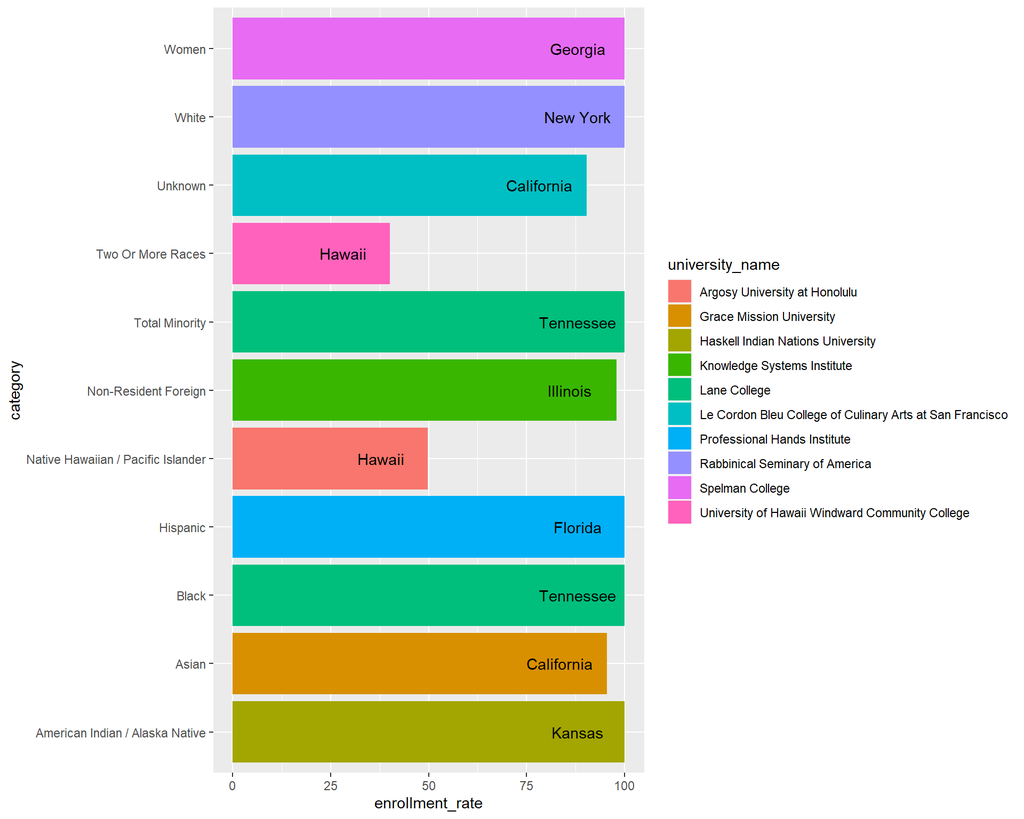

# Diversity map of the US for each diversity group

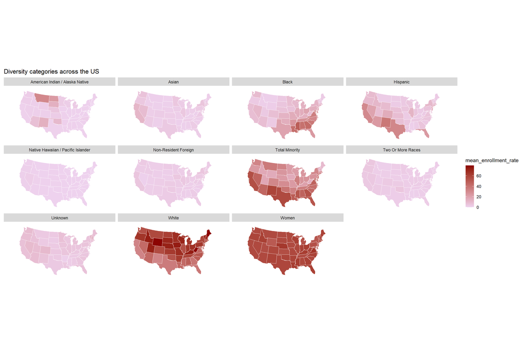

# Women enrollment rate across the US

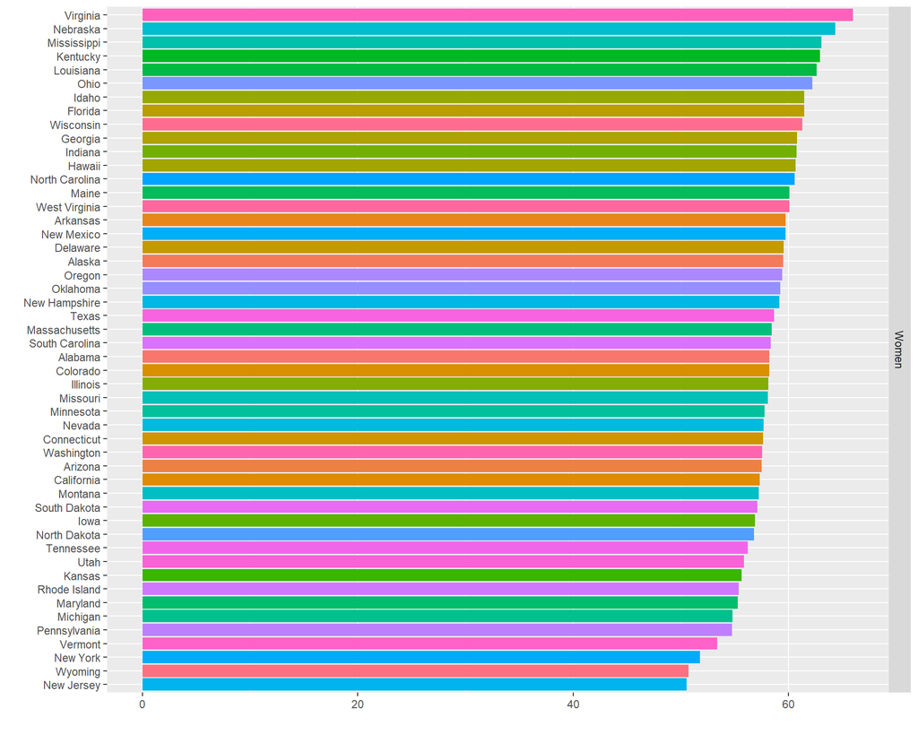

# Tuition cost dataset

```r
tuition_cost %>% glimpse()
```

```
## Rows: 2,973
## Columns: 10
## $ name                 <chr> "Aaniiih Nakoda College", "Abilene Christian U...
## $ state                <chr> "Montana", "Texas", "Georgia", "Minnesota", "C...
## $ state_code           <chr> "MT", "TX", "GA", "MN", "CA", "CO", "NY", "NY"...
## $ type                 <chr> "Public", "Private", "Public", "For Profit", "...
## $ degree_length        <chr> "2 Year", "4 Year", "2 Year", "2 Year", "4 Yea...
## $ room_and_board       <dbl> NA, 10350, 8474, NA, 16648, 8782, 16030, 11660...
## $ in_state_tuition     <dbl> 2380, 34850, 4128, 17661, 27810, 9440, 38660, ...
## $ in_state_total       <dbl> 2380, 45200, 12602, 17661, 44458, 18222, 54690...
## $ out_of_state_tuition <dbl> 2380, 34850, 12550, 17661, 27810, 20456, 38660...
## $ out_of_state_total   <dbl> 2380, 45200, 21024, 17661, 44458, 29238, 54690...
```

### Merge tuition cost dataset and diversity dataset

- We are interested to know whether there is any correlation between enrollment rate and each diversity group
- We have done analysis for both in state and out of state tuition in the next slides

# Relationship between enrollment rate and in-state-tuition per each diversity group

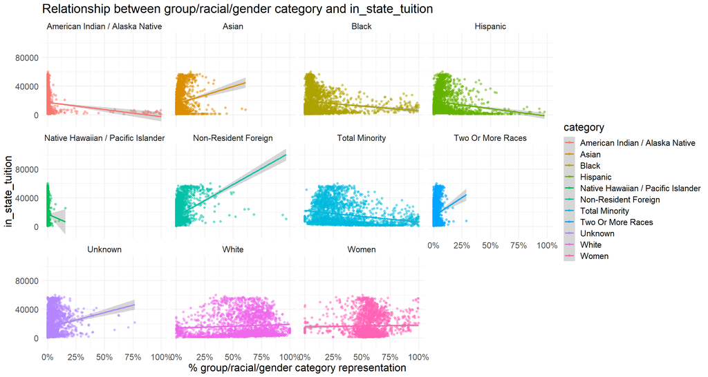

# Relationship between enrollment rate and out-of-state tuition per each diversity group

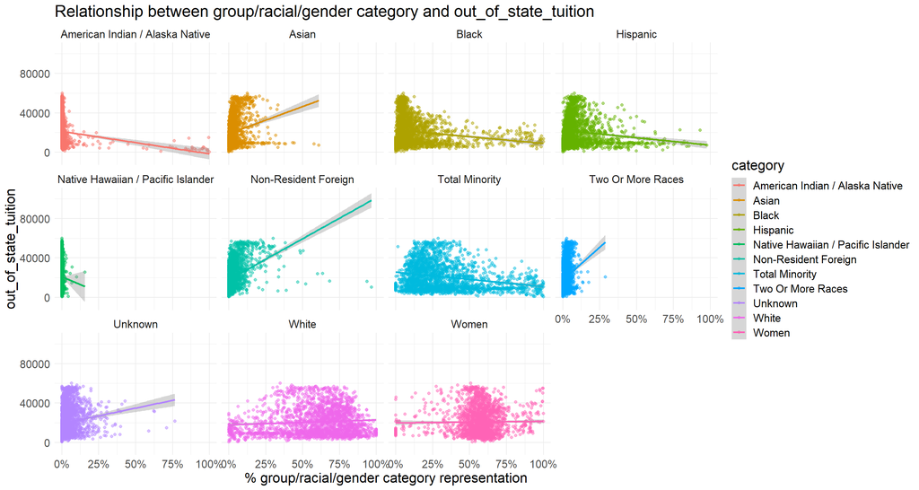

# Relationship between diversity groups enrollment rate and early career salary

- we need to merge diversity dataset and salary dataset.

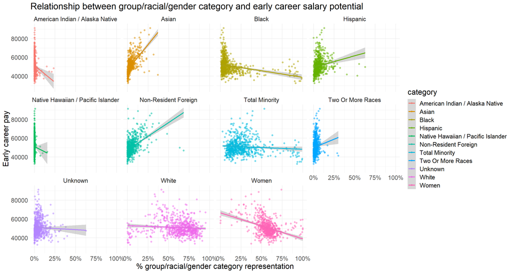

# Different types of colleges in US

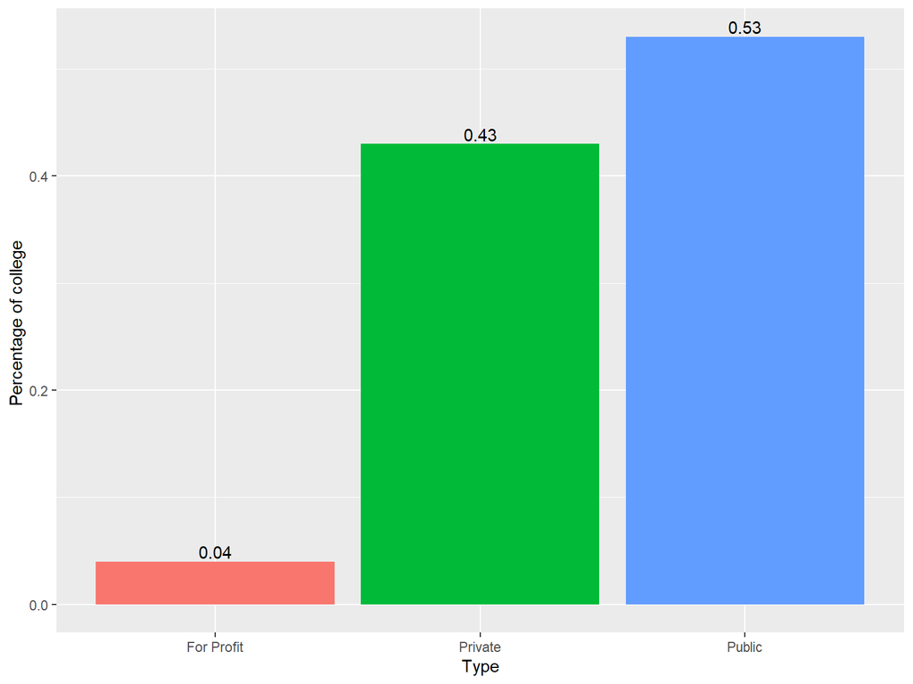

# How many colleges are there in each state?

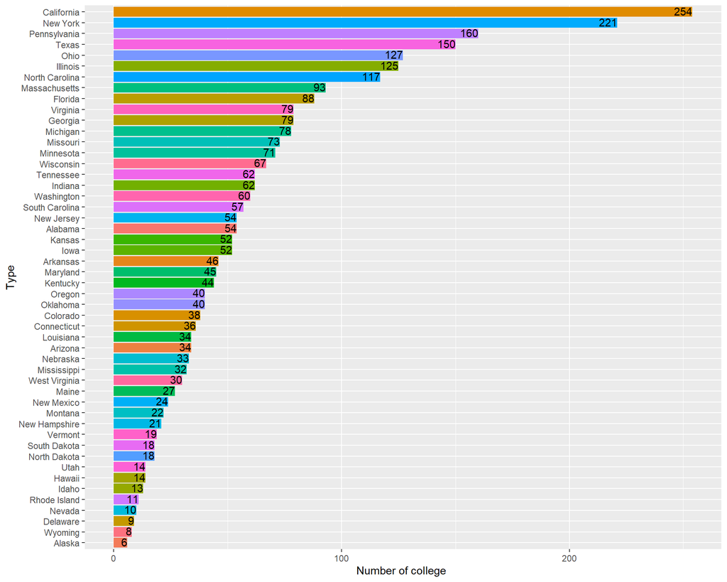

# Comparing different states in terms of in state and out of state tuition

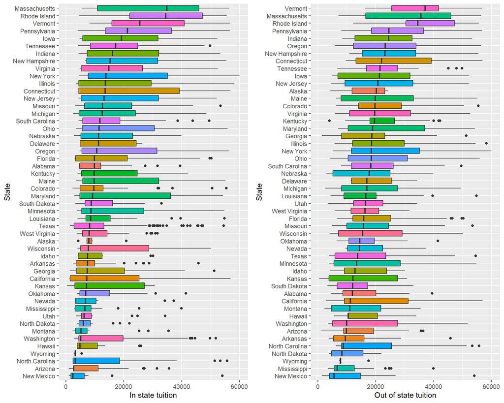

# Comparing in/out-of state tuition

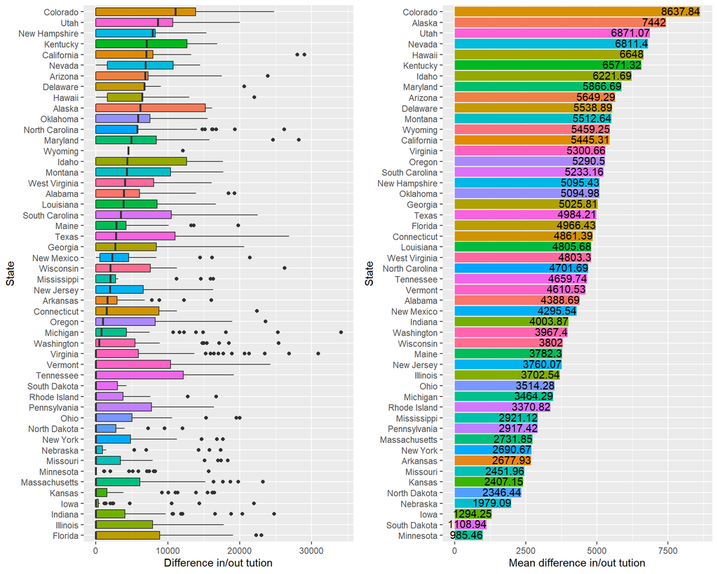

# In-state tuition, different type of colleges; What is the relationship?

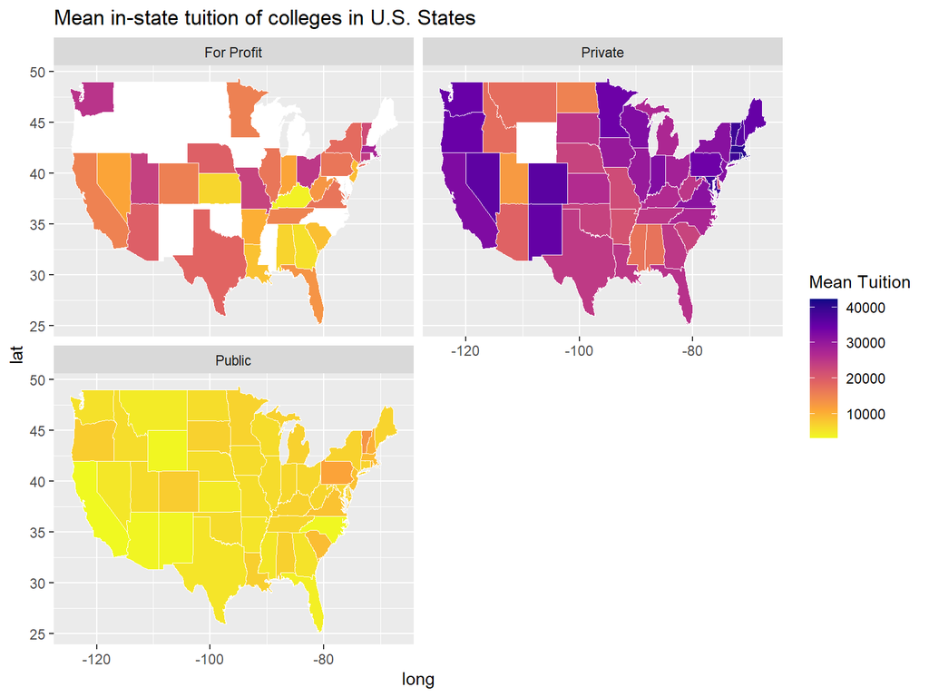

# Out-of-state tuition, different type of colleges; What is the relationship?

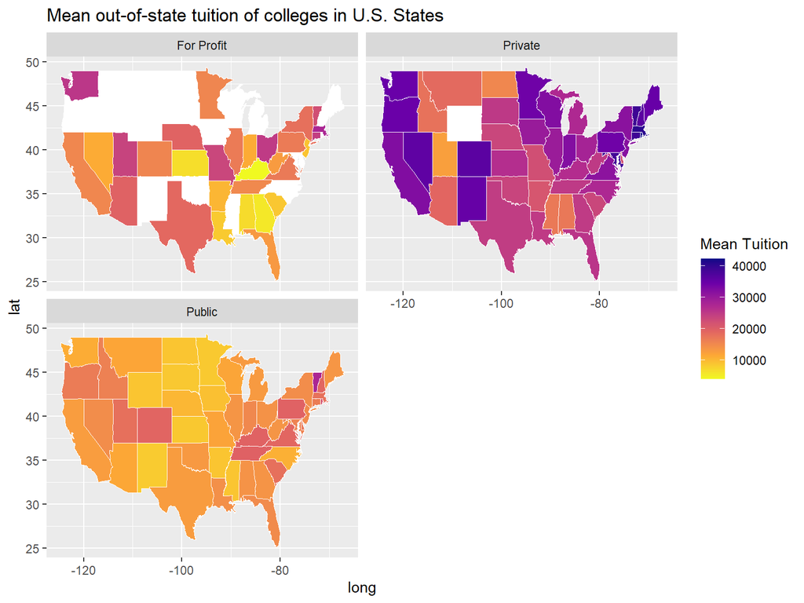

# The chepeast/most expensive colleges with out-of-state tuition

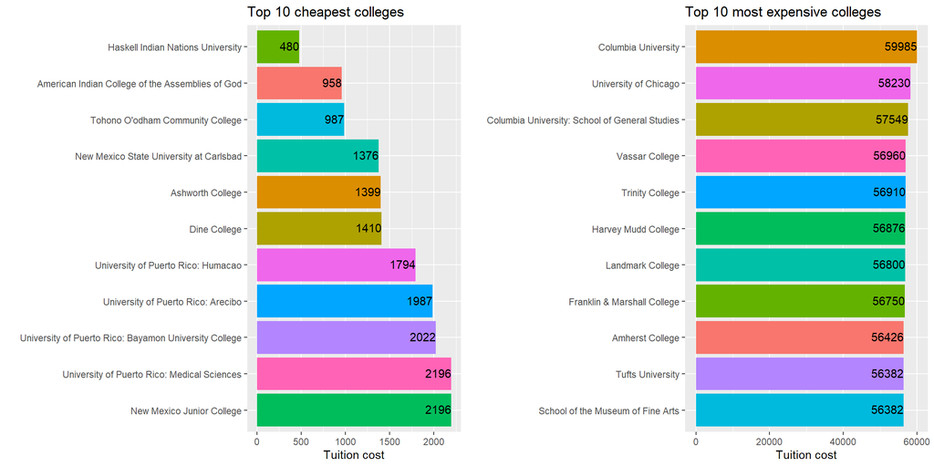

# The cheapest/most expensive colleges with in-state tuition

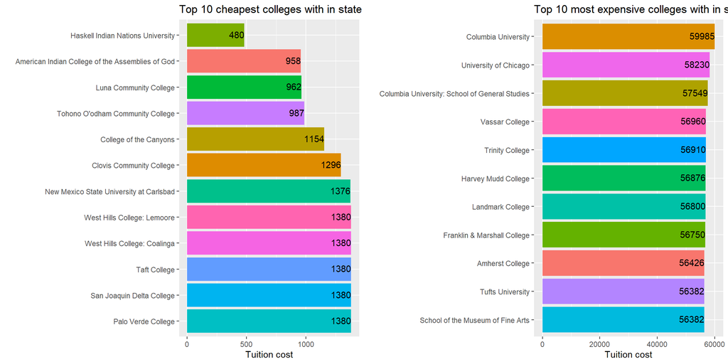

# The historical tuition dataset

### 270 observations and 4 variables

| type | year | tuition_type | tuition_cost |
| --- | --- | --- | --- |
| All Institutions | 1985-86 | All Constant | 10893 |
| All Institutions | 1985-86 | 4 Year Constant | 12274 |
| All Institutions | 1985-86 | 2 Year Constant | 7508 |
| All Institutions | 1985-86 | All Current | 4885 |
| All Institutions | 1985-86 | 4 Year Current | 5504 |
| All Institutions | 1985-86 | 2 Year Current | 3367 |

# The historical tuition dataset

#### We observe that the data is available consistantly from 2000 till 2017.

```
##  [1] "1985-86" "1995-96" "2000-01" "2001-02" "2002-03" "2003-04" "2004-05"
##  [8] "2005-06" "2006-07" "2007-08" "2008-09" "2009-10" "2010-11" "2011-12"
## [15] "2012-13" "2013-14" "2014-15" "2015-16" "2016-17"
```

#### For convinience, we will consider the end of year.

```
##  [1] 1986 1996 2001 2002 2003 2004 2005 2006 2007 2008 2009 2010 2011 2012 2013
## [16] 2014 2015 2016 2017
```

# Average tuition cost over time

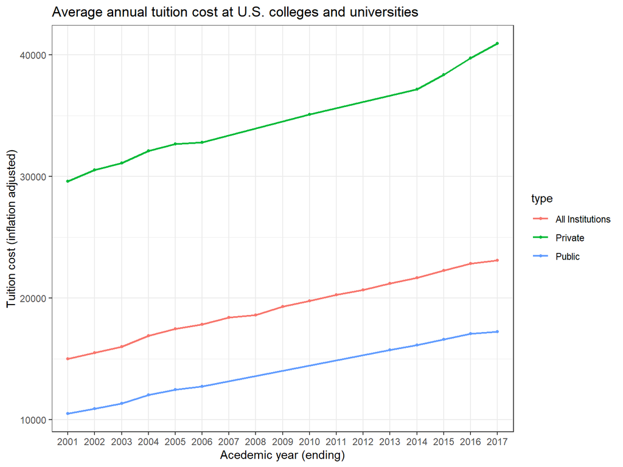

# Tuition comparison between 2 year and 4 year programs

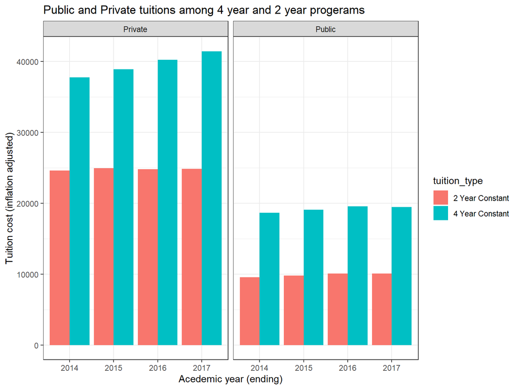

# Salary potential dataset

### 935 observations and 6 variables including:

| rank | name | state_name | early_career_pay | mid_career_pay | stem_percent |
| --- | --- | --- | --- | --- | --- |
| 1 | Auburn University | Alabama | 54400 | 104500 | 31 |
| 2 | University of Alabama in Huntsville | Alabama | 57500 | 103900 | 45 |
| 3 | The University of Alabama | Alabama | 52300 | 97400 | 15 |
| 4 | Tuskegee University | Alabama | 54500 | 93500 | 30 |
| 5 | Samford University | Alabama | 48400 | 90500 | 3 |
| 6 | Spring Hill College | Alabama | 46600 | 89100 | 12 |

# Which states have the highest/least potential salary?

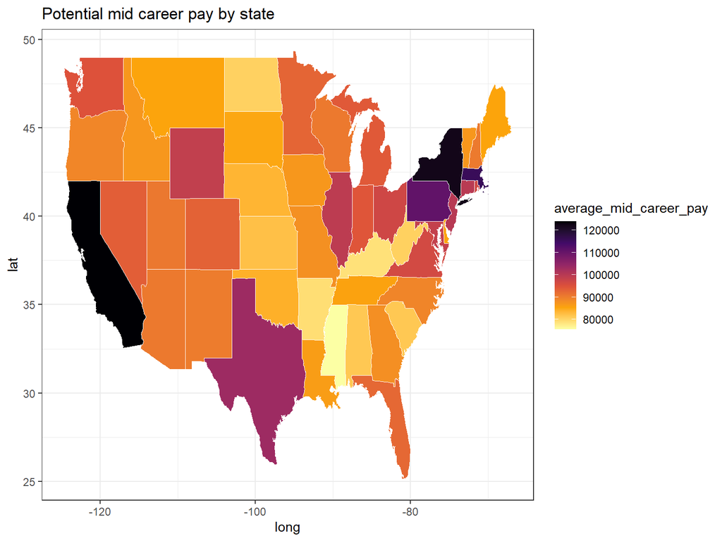

# Top 5 states

| state_name | average_mid_career_pay |
| --- | --- |
| California | 123976 |
| New-York | 122328 |
| Massachusetts | 115712 |
| Pennsylvania | 110884 |
| Texas | 103476 |

| state_name | average_early_career_pay |
| --- | --- |
| California | 67232 |
| New-York | 66688 |
| Massachusetts | 63100 |
| Pennsylvania | 60644 |
| Texas | 57468 |

# Let’s take a closer look at Iowa

| rank | name | state_name | early_career_pay | mid_career_pay | stem_percent |
| --- | --- | --- | --- | --- | --- |
| 1 | Iowa State University | Iowa | 56100 | 101300 | 31 |
| 2 | Drake University | Iowa | 52800 | 99900 | 7 |
| 3 | University of Iowa | Iowa | 54100 | 99400 | 16 |
| 4 | Grinnell College | Iowa | 53400 | 96500 | 41 |
| 5 | Allen College | Iowa | 51600 | 91300 | 0 |
| 6 | Cornell College | Iowa | 49600 | 90600 | 22 |
| 7 | Loras College | Iowa | 48000 | 90100 | 14 |
| 8 | Dordt College | Iowa | 51000 | 89600 | 17 |
| 9 | Central College | Iowa | 49000 | 88800 | 36 |
| 10 | Graceland University-Lamoni | Iowa | 48300 | 88700 | 5 |
| 11 | Simpson College | Iowa | 49900 | 88600 | 17 |
| 12 | Wartburg College | Iowa | 49300 | 88000 | 34 |
| 13 | Coe College | Iowa | 47200 | 86900 | 24 |
| 14 | Luther College | Iowa | 48200 | 85900 | 21 |
| 15 | University of Northern Iowa | Iowa | 47100 | 85300 | 8 |
| 16 | Maharishi University of Management | Iowa | 46800 | 85200 | 65 |
| 17 | Saint Ambrose University | Iowa | 46900 | 84400 | 8 |
| 18 | Northwestern College | Iowa | 44800 | 82400 | 11 |
| 19 | Morningside College | Iowa | 44900 | 82100 | 6 |
| 20 | Clarke University | Iowa | 44900 | 80200 | 6 |
| 21 | University of Dubuque | Iowa | 44200 | 79700 | 7 |
| 22 | Mount Mercy University | Iowa | 47200 | 79000 | 4 |
| 23 | William Penn University | Iowa | 43900 | 78300 | 7 |
| 24 | Upper Iowa University | Iowa | 44200 | 78000 | 3 |
| 25 | Iowa Wesleyan University | Iowa | 42600 | 77200 | 8 |

# In Iowa, ISU has the highest potential salary

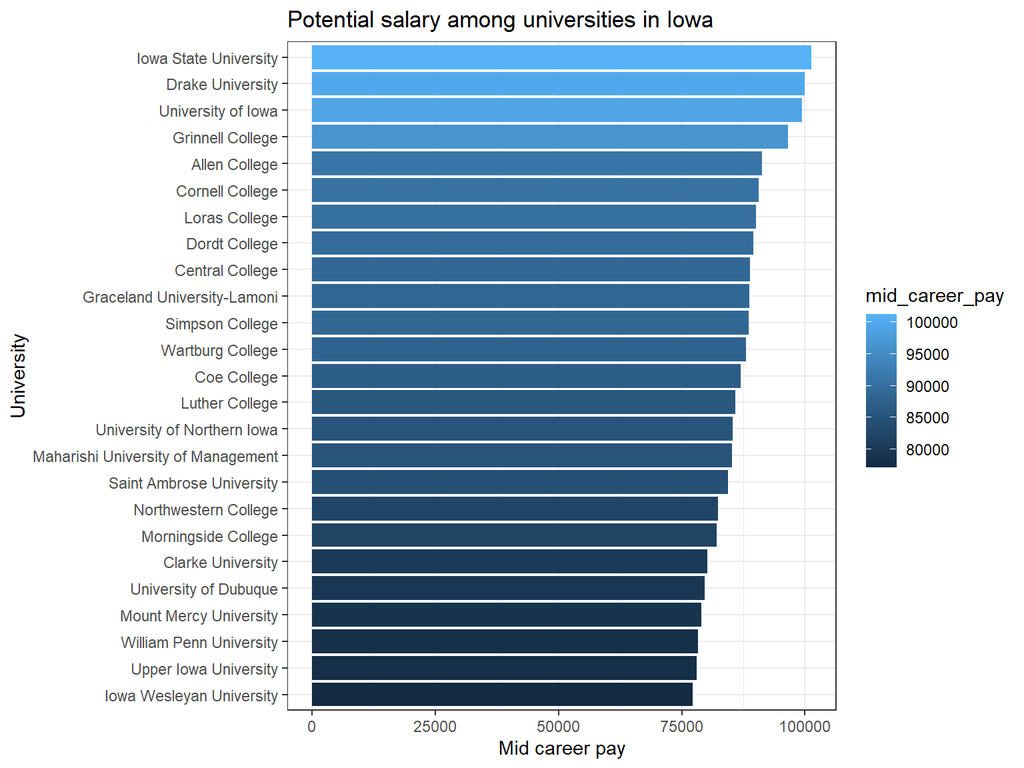

# What is average stem percent across different states?

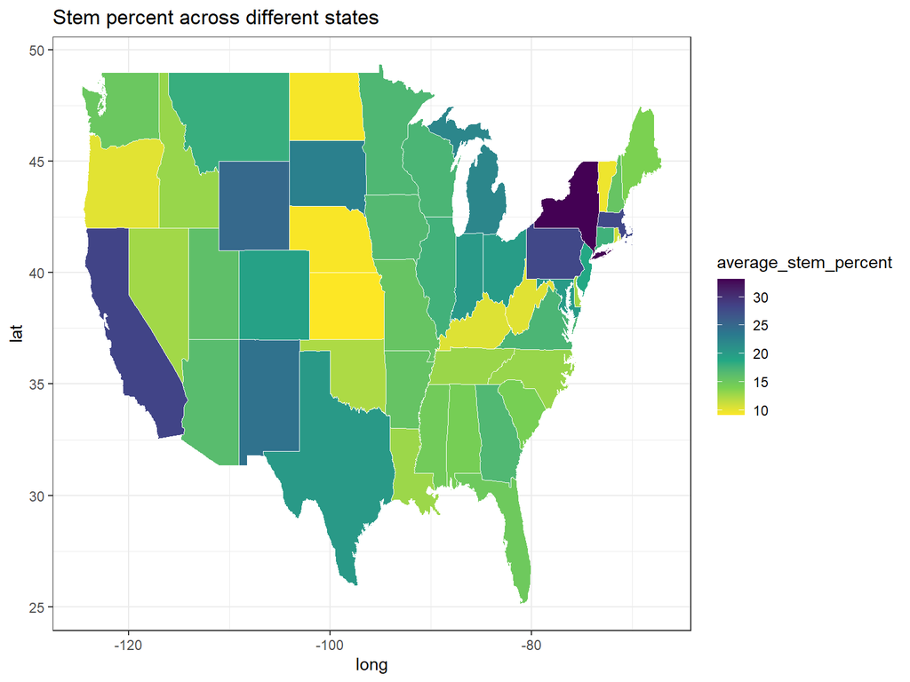

# Conclusions

- The map of diversity across the US indicates that the US colleges are not equally diverse geographically.
- There is relationship between different diversity groups, tuition and early career salary.
- Average out-of-state tuition differs across the country while average in-state tuition remains almost the same.
- East coast colleges are more expensive in terms of in-state and out-of-state tuition.
- Massachusetts has the highest in-state tuition.
- Private schools cost more than public schools.
- Historical trend of tuition showed that tuition is increasing over time.
- Universities located in west/east coast have higher stem percent and also higher potential salary.